# Medicare Utilization Analysis Project (Inferential Model)

## Utilizing machine learning to discover trends in Medicare data

## Introduction

This project is meant to take in data about Medicare beneficiaries and run it through a machine learning model so that we can gain meaningful insights about trends in the data. This type of machine learning model process is called an inferential machine learning model. The data is taken from the official cms.gov website and is public data called the Medicare Current Beneficiary Survey (MCBS). The end goal is to find out if the public data from the cms.gov website will reveal any problems with how Medicare is being run. This could be found out by running it through the model and checking which features contributed most to predicting the result.

## Initial Thoughts and Motive

When brainstorming a project to do for this class, I wanted to create something that was significant and applicable in the real world, and interesting to me personally. Medicare data seemed like a perfect fit for it since it was free and publicly available, but also had lots of real world applications. Furthermore, as a college student with grandparents eligible for Medicare, I was curious on how the Medicare system worked and how I might be able to help and support them. Hopefully, these findings can be used in an even broader range of ideas and topics and I can learn more about something I care about.

## What is Medicare?

Medicare is the U.S. federal health insurance program primarily for people 65 and older, as well as some younger people with disabilities or specific conditions like end-stage kidney disease. Its main goals are:

- Access to care: Ensure elderly and disabled Americans have access to healthcare regardless of income, since these groups often can't get affordable private insurance on their own.
- Financial protection: Protect beneficiaries from catastrophic medical costs that could wipe out their savings because medical bills are one of the biggest causes of financial hardship for older Americans.
- Health equity: Before Medicare was created in 1965, roughly half of seniors had no health insurance at all. Medicare dramatically reduced that gap, particularly for lower-income and minority populations.
- Supporting the healthcare system: Because Medicare covers such a large share of the population, it also serves as a major driver of healthcare policy. Therefore, it sets reimbursement rates, quality standards, and payment models that the broader healthcare industry tends to follow.

There are four main parts to Medicare.

- Part A: Hospital insurance (inpatient stays, skilled nursing, hospice)
- Part B: Medical insurance (doctor visits, outpatient care, preventive services)
- Part C: Medicare Advantage (private insurance plans that bundle A + B, sometimes with extras like dental/vision)
- Part D: Prescription drug coverage

These can be split into two main sections:

- FFS (Fee-for-Service): Parts A and B together, traditional Medicare, where the government pays per service
- MA (Medicare Advantage): Part C, a private plan alternative

These sections' definitions will be significant in future parts of this report.

## Explanation of Data

The data used in this project is taken directly from the CMS.gov website. As listed on the website, CMS is "the federal agency that provides health coverage to more than 160 million through Medicare, Medicaid, the Children's Health Insurance Program, and the Health Insurance Marketplace. CMS works in partnership with the entire health care community to improve quality, equity and outcomes in the health care system." Our data is specifically taken from MCBS (Medicare Current Beneficiary Survey), which is a survey of actual Medicare beneficiaries that collects information on their health, demographics, and how much healthcare they use. It is taken each year periodically during each season of the year. This data is from 2020-2023 and uses the surveys taken in the fall and winter periods of each year. More information can be found about the data and where it is from here: https://www.cms.gov/data-research/research/medicare-current-beneficiary-survey

There is also a codebook attached to this assignment that explains each variable in greater detail. These codebooks were taken directly from the website.

Formal Citation: Centers for Medicare & Medicaid Services. Medicare Current Beneficiary Survey (MCBS). U.S. Department of Health and Human Services, 2026, www.cms.gov/data-research/research/medicare-current-beneficiary-survey. Accessed 7 June 2026.

## Project Outline

This project will follow a couple steps in order to find out reveal trends in Medicare. First, it will take in the data from the MCBS, combining it all into one dataset. From there, exploratory data analysis will be used to figure out which variables are significant to be used. In order to reveal trends in Medicare by using machine learning, I will create a "utilization score" using data from the survey that organizes features from the dataset into one score that determines how well each person is utilizing their Medicare benefits. The other variables will be used to predict this score. By running it through a machine learning model and observing the results of most important features and other things, I will be able to understand the correlation of variables and utilization. After observing all the results, I will compile a report of the findings.

### Setting up the file and importing libraries

```python
import pandas as pd
import numpy as np
import matplotlib.pyplot as plt
import seaborn as sns
import warnings

from sklearn.model_selection import train_test_split, cross_val_score, KFold
from sklearn.preprocessing import StandardScaler, MinMaxScaler
from sklearn.metrics import r2_score, mean_squared_error, mean_absolute_error
from sklearn.linear_model import LinearRegression, Ridge, Lasso, ElasticNet
from sklearn.ensemble import RandomForestRegressor, GradientBoostingRegressor
from sklearn.tree import DecisionTreeRegressor
from sklearn.decomposition import PCA
from sklearn.impute import SimpleImputer
from sklearn.model_selection import StratifiedKFold
import xgboost as xgb
from xgboost import plot_importance

import statsmodels.api as sm
from scipy import stats
from statsmodels.stats.stattools import durbin_watson
from statsmodels.stats.diagnostic import het_breuschpagan, het_white
from statsmodels.stats.outliers_influence import variance_inflation_factor
from statsmodels.graphics.gofplots import qqplot
import shap

warnings.filterwarnings('ignore')
pd.set_option('display.max_columns', None)
pd.set_option('display.width', None)
plt.rcParams['figure.figsize'] = (12, 6)
plt.rcParams['figure.dpi'] = 100
```

## Loading and Merging the Data

```python
base_path = "/Users/ethanc/medicare project/Medicare Current Beneficiary Survey - Survey File"

fall_files = [
    f"{base_path}/2020/SFPUF2020_Data/sfpuf2020_1_fall.csv",
    f"{base_path}/2021/SFPUF2021_Data/sfpuf2021_1_fall.csv",
    f"{base_path}/2022/SFPUF2022_Data/sfpuf2022_1_fall.csv",
    f"{base_path}/2023/SFPUF2023_Data/sfpuf2023_1_fall.csv",
]
winter_files = [
    f"{base_path}/2020/SFPUF2020_Data/sfpuf2020_2_winter.csv",
    f"{base_path}/2021/SFPUF2021_Data/sfpuf2021_2_winter.csv",
    f"{base_path}/2022/SFPUF2022_Data/sfpuf2022_2_winter.csv",
    f"{base_path}/2023/SFPUF2023_Data/sfpuf2023_2_winter.csv",
]

fall = pd.concat([pd.read_csv(f) for f in fall_files], ignore_index=True)
winter = pd.concat([pd.read_csv(f) for f in winter_files], ignore_index=True)
winter_to_merge = winter.drop(columns=['SURVEYYR', 'VERSION'])
df_all = fall.merge(winter_to_merge, on='PUF_ID', how='inner')
print(f"Merged dataset: {df_all.shape[0]:,} rows × {df_all.shape[1]} columns")
```

```
Merged dataset: 43,833 rows × 577 columns
```

## Data Cleaning

After checking the codebook, I sorted the variables into columns that have a high likelyhood of impacting the utilization score and columns that make up the utilization score.

```python
drop_prefix = ['PUFF', 'PUFW']
df_all = df_all[[c for c in df_all.columns if not any(c.startswith(p) for p in drop_prefix)]]

# High correlation columns
high_cols = [
    "HLT_GENHELTH", "HLT_COMPHLTH", "HLT_FUNC_LIM", "HLT_D_LSTADL",
    "HLT_OCBETES", "HLT_OCHBP", "HLT_OCCFAIL", "HLT_OCCHD", "HLT_OCMYOCAR",
    "HLT_OCSTROKE", "HLT_OCEMPHYS", "HLT_OCKIDNY", "HLT_OCCANCER",
    "HLT_ALZDEM", "HLT_OCDEPRSS", "HLT_OCPSYCHO",
    "HLT_DISDECSN", "HLT_DISWALK", "HLT_DISBATH", "HLT_DISERRND",
    "HLT_BMI_CAT", "HLT_HELMTACT", "DEM_AGE", "DEM_SEX", "DEM_INCOME", "DEM_IPR_IND",
    "ADM_OP_MDCD", "ADM_DUAL_FLAG_YR", "ADM_FFS_FLAG_YR", "ADM_LIS_FLAG_YR",
    "FAL_FALLANY", "ACC_HCTROUBL", "ACC_HCDELAY", "ACC_PAYPROB",
    "HLT_DTBLGTPL", "HLT_DREDTRAV", "ACW_CARESPCL",
]

high_cols = [
    "HLT_GENHELTH", "HLT_COMPHLTH", "HLT_FUNC_LIM", "HLT_D_LSTADL",
    "HLT_OCBETES", "HLT_OCHBP", "HLT_OCCFAIL", "HLT_OCCHD", "HLT_OCMYOCAR",
    "HLT_OCSTROKE", "HLT_OCEMPHYS", "HLT_OCKIDNY", "HLT_OCCANCER",
    "HLT_ALZDEM", "HLT_OCDEPRSS", "HLT_OCPSYCHO",
    "HLT_DISDECSN", "HLT_DISWALK", "HLT_DISBATH", "HLT_DISERRND",
    "HLT_BMI_CAT", "HLT_HELMTACT", "DEM_AGE", "DEM_SEX", "DEM_INCOME", "DEM_IPR_IND",
    "ADM_OP_MDCD", "ADM_DUAL_FLAG_YR", "ADM_FFS_FLAG_YR", "ADM_MA_FLAG_YR", "ADM_LIS_FLAG_YR",
    "FAL_FALLANY", "FAL_FALLHELP", "FAL_FALFRACT", "ACC_HCTROUBL","ACC_HCTRBMNY",
    "ACC_HCDELAY", "ACC_PAYPROB", "HLT_DTBLGTPL", "HLT_DREDTRAV", "ACW_PLACEPAR", "ACW_USUALDOC", "ACW_CARESPCL",
    ]



# Utilization columns
util_cols = [
    "ADM_H_ACTSTY", "ADM_H_ACTDAY", "ADM_H_SNFSTY", "ADM_H_SNFDAY",
    "ADM_H_HHVIS", "ADM_H_PHYEVT",
    "ADM_H_INPSW", "ADM_H_OUTSW", "ADM_H_PBSW",
    "ADM_H_SNFSW", "ADM_H_HHASW", "ADM_H_HOSSW",
    "ACW_D_ERVIST", "ACW_D_OPVIST", "ACW_HOSADMIT",
]



keep_cols = high_cols + util_cols
df_filtered = df_all[[col for col in keep_cols if col in df_all.columns]].copy()

# Convert everything to numeric
for col in df_filtered.columns:
    df_filtered[col] = pd.to_numeric(df_filtered[col], errors='coerce')

# Recode binary vars: 1=Yes→1, 2=No→0
recode_binary = [
    "HLT_OCBETES", "HLT_OCHBP", "HLT_OCCFAIL", "HLT_OCCHD", "HLT_OCMYOCAR",
    "HLT_OCSTROKE", "HLT_OCEMPHYS", "HLT_OCKIDNY", "HLT_OCCANCER",
    "HLT_ALZDEM", "HLT_OCDEPRSS", "HLT_OCPSYCHO",
    "HLT_DISDECSN", "HLT_DISWALK", "HLT_DISBATH", "HLT_DISERRND",
    "HLT_DTBLGTPL", "HLT_DREDTRAV",
    "FAL_FALLANY", "ACC_HCTROUBL", "ACC_HCDELAY", "ACC_PAYPROB", "DEM_SEX",
]
for col in recode_binary:
    if col in df_filtered.columns:
        df_filtered[col] = df_filtered[col].map({1: 1, 2: 0})

print(f"Clean dataset: {df_filtered.shape[0]:,} rows × {df_filtered.shape[1]} columns")
```

```
Clean dataset: 43,833 rows × 58 columns
```

## Exploratory Data Analysis

In order to find out which variables to use, I performed exploratory data analysis to see which variables had missing entries and therefore could not be used, and looked through the codebook from the website to determine which variables would be helpful in figuring out what the utilization score is and which would be helpful in predicting the utilization score.

#### Missingness Graph

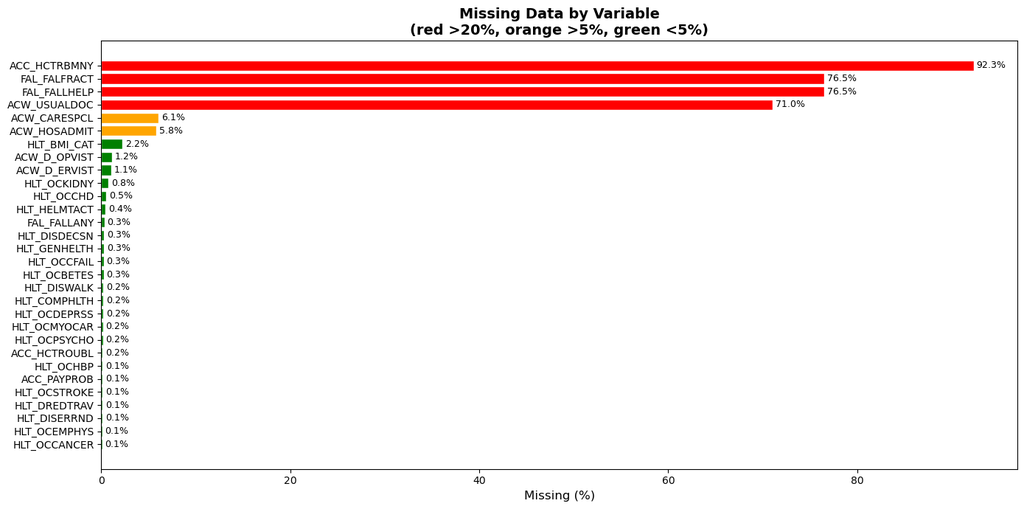

```python
missing_pct = (df_filtered.isna().sum() / len(df_filtered) * 100).sort_values(ascending=True)
cols_with_missing = missing_pct[missing_pct > 0].tail(30)

fig, ax = plt.subplots(figsize=(14, 7))
colors = ['red' if p > 20 else 'orange' if p > 5 else 'green' for p in cols_with_missing]
ax.barh(cols_with_missing.index, cols_with_missing.values, color=colors, edgecolor='white')
ax.set_xlabel('Missing (%)', fontsize=12)
ax.set_title('Missing Data by Variable\n(red >20%, orange >5%, green <5%)', fontsize=14, fontweight='bold')
for i, (val, name) in enumerate(zip(cols_with_missing.values, cols_with_missing.index)):
    ax.text(val + 0.3, i, f'{val:.1f}%', va='center', fontsize=9)
plt.tight_layout()
plt.show()
```

```python
df_filtered = df_filtered.drop(['ACC_HCTRBMNY', 'FAL_FALLHELP', 'FAL_FALFRACT', 'ACW_USUALDOC'], axis=1)
df_filtered = df_filtered.dropna()
print(f"Clean dataset: {df_filtered.shape[0]:,} rows × {df_filtered.shape[1]} columns")
```

```
Clean dataset: 38,241 rows × 54 columns
```

## PCA-Based Utilization Score

Now that the variables have been seperated into utilization varaibles and predictor variables, I can create a utilization score for each datapoint through a process called PCA. Principal Component Analysis (PCA) is a dimensionality reduction technique. When you have many correlated variables (like multiple utilization measures), PCA finds new summary variables that are uncorrelated with each other and capture as much of the original variation as possible.

```python
util_df = df_filtered[util_cols].copy()


# Recode utilization binary variables
binary_int_cols = ["ADM_H_INPSW", "ADM_H_OUTSW", "ADM_H_PBSW",
                   "ADM_H_SNFSW", "ADM_H_HHASW", "ADM_H_HOSSW"]
binary_obj_cols = ["ACW_D_ERVIST", "ACW_D_OPVIST", "ACW_HOSADMIT"]
count_cols = ["ADM_H_ACTSTY", "ADM_H_ACTDAY", "ADM_H_SNFSTY",
              "ADM_H_SNFDAY", "ADM_H_HHVIS", "ADM_H_PHYEVT"]

for col in binary_int_cols:
    util_df[col] = util_df[col].map({1: 1, 2: 0}).fillna(df_filtered[col].median())
for col in binary_obj_cols:
    util_df[col] = util_df[col].astype(str).map({'1': 1, '1.0': 1, '2': 0, '2.0': 0}).fillna(0)
for col in count_cols:
    util_df[col] = util_df[col].fillna(df_filtered[col].median())

# Standardize before PCA
util_scaler = StandardScaler()
util_scaled = util_scaler.fit_transform(util_df)

# Full PCA to see variance explained
pca_full = PCA(n_components=len(util_cols))
pca_full.fit(util_scaled)

print("Variance Explained by Each Component")
for i, (var, cum) in enumerate(zip(pca_full.explained_variance_ratio_,
                                     np.cumsum(pca_full.explained_variance_ratio_))):
    print(f"  PC{i+1:2d}: {var:.4f} ({cum:.4f} cumulative)")
```

```
Variance Explained by Each Component
  PC 1: 0.3500 (0.3500 cumulative)
  PC 2: 0.1545 (0.5045 cumulative)
  PC 3: 0.1192 (0.6237 cumulative)
  PC 4: 0.0845 (0.7083 cumulative)
  PC 5: 0.0705 (0.7787 cumulative)
  PC 6: 0.0668 (0.8455 cumulative)
  PC 7: 0.0596 (0.9051 cumulative)
  PC 8: 0.0338 (0.9389 cumulative)
  PC 9: 0.0235 (0.9624 cumulative)
  PC10: 0.0162 (0.9786 cumulative)
  PC11: 0.0093 (0.9879 cumulative)
  PC12: 0.0082 (0.9961 cumulative)
  PC13: 0.0037 (0.9998 cumulative)
  PC14: 0.0002 (1.0000 cumulative)
  PC15: 0.0000 (1.0000 cumulative)
```

```python
# Create PCA utilization score
pca_scores = pca_full.transform(util_scaled)
pc1_raw = pca_scores[:, 0]

# Flip sign if needed so higher = more utilization
raw_total = util_df[count_cols].sum(axis=1) + util_df[binary_int_cols + binary_obj_cols].sum(axis=1)
if np.corrcoef(pc1_raw, raw_total)[0, 1] < 0:
    pc1_raw = -pc1_raw

# Normalize 0-100, then log-transform
pc1_norm = ((pc1_raw - pc1_raw.min()) / (pc1_raw.max() - pc1_raw.min()) * 100).round(2)

high_cols = [item for item in high_cols if item not in ['FAL_FALLHELP', 'FAL_FALFRACT', 'ACC_HCTRBMNY', 'ACW_USUALDOC']]
df = df_filtered[high_cols].copy()
df["util_pca_raw"] = pc1_norm
df["utilization_score"] = np.log1p(pc1_norm)

print(f"PCA target (raw) — mean: {df['util_pca_raw'].mean():.2f}, median: {df['util_pca_raw'].median():.2f}")
print(f"PCA target (log) — mean: {df['utilization_score'].mean():.2f}, median: {df['utilization_score'].median():.2f}")
print(f"Zero utilization: {(df['util_pca_raw'] == 0).sum():,} ({(df['util_pca_raw'] == 0).mean():.1%})")
```

```
PCA target (raw) — mean: 4.19, median: 2.09
PCA target (log) — mean: 1.09, median: 1.13
Zero utilization: 10,542 (27.6%)
```

After running it through the PCA process, we now have a dataframe with all of our predictors and our target variable, utilization_score. We can observe what this variable looks like by plotting it into some graphs.

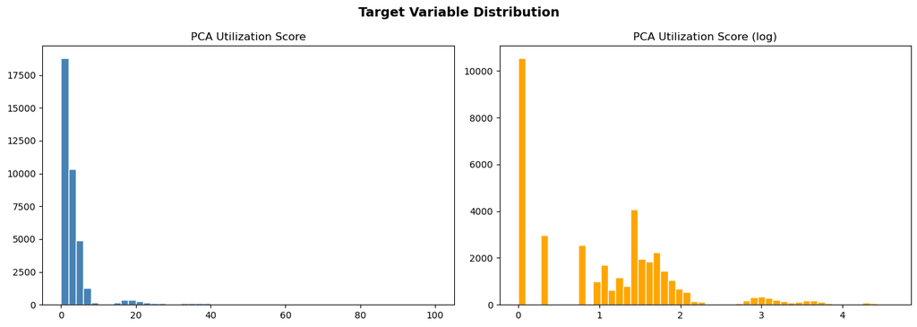

```python
fig, axes = plt.subplots(1, 2, figsize=(14, 5))
axes[0].hist(df["util_pca_raw"], bins=50, edgecolor='white', color='steelblue')
axes[0].set_title("PCA Utilization Score")
axes[1].hist(df["utilization_score"], bins=50, edgecolor='white', color='orange')
axes[1].set_title("PCA Utilization Score (log)")
plt.suptitle("Target Variable Distribution", fontsize=14, fontweight='bold')
plt.tight_layout()
plt.show()
```

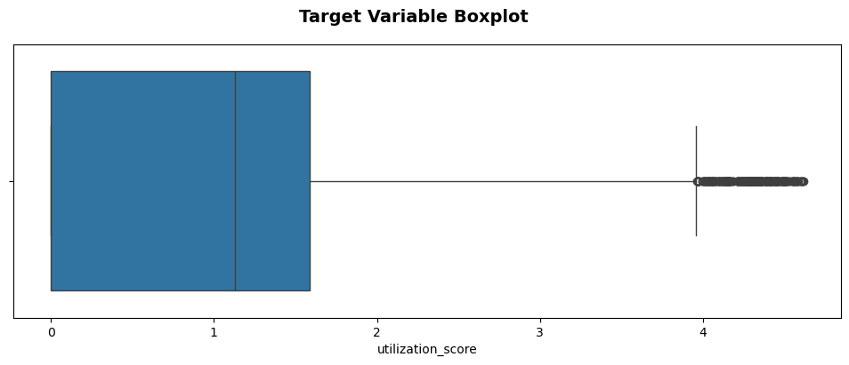

```python
plt.figure(figsize=(12, 4))
sns.boxplot(x=df['utilization_score'])
plt.suptitle("Target Variable Boxplot", fontsize=14, fontweight='bold')
```

### Correlation Heatmap

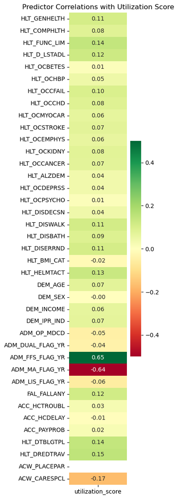

```python
for col in high_cols:
    df[col] = pd.to_numeric(df[col], errors='coerce')
corr = df[high_cols + ["utilization_score"]].corr()[["utilization_score"]].drop("utilization_score")

plt.figure(figsize=(4, 12))
sns.heatmap(corr, annot=True, fmt=".2f", cmap="RdYlGn", center=0, vmin=-0.5, vmax=0.5)
plt.title("Predictor Correlations with Utilization Score")
plt.tight_layout()
plt.show()
```

This correlation heatmaps gives us a good idea of what variables are related to the utilization score and which ones might help predict it. The notable one that stands out is ADM_FFS_FLAG_YR, which represents whether or not the user is Fee-for-Service. However, this heatmap now shows us a different problem. ADM_MA_FLAG_YR and ADM_FFS_FLAG_YR have the same correlation with each other, but are the inverse of each other. This is likely a cause of multicollinearity, which we will fix in the next section

### VIF — Multicollinearity Check

```python
X_vif = df[high_cols].fillna(df[col].median())
X_vif_scaled = StandardScaler().fit_transform(X_vif)

vif_data = pd.DataFrame({
    "feature": high_cols,
    "VIF": [variance_inflation_factor(X_vif_scaled, i) for i in range(X_vif_scaled.shape[1])]
}).sort_values("VIF", ascending=False)

print("Features with VIF > 5:")
high_vif = vif_data[vif_data['VIF'] > 5]
print(high_vif.to_string(index=False) if len(high_vif) > 0 else "  None — no multicollinearity issues.")

df = df.drop(['ADM_MA_FLAG_YR', 'ADM_DUAL_FLAG_YR', 'ADM_LIS_FLAG_YR'], axis=1)
df = df.dropna()
high_cols = [item for item in high_cols if item not in ['ADM_MA_FLAG_YR', 'ADM_DUAL_FLAG_YR', 'ADM_LIS_FLAG_YR']]
```

```
Features with VIF > 5:
         feature        VIF
  ADM_MA_FLAG_YR 153.664138
 ADM_FFS_FLAG_YR 153.555716
ADM_DUAL_FLAG_YR   9.057045
 ADM_LIS_FLAG_YR   6.871325
```

### Train/Test Split

```python
strat_bins = pd.qcut(df["utilization_score"], q=4, labels=False, duplicates='drop')
train_idx, test_idx = train_test_split(
    df.index, test_size=0.2, random_state=67, stratify=strat_bins
)
print(f"Train: {len(train_idx):,} samples")
print(f"Test:  {len(test_idx):,} samples")
```

```
Train: 30,592 samples
Test:  7,649 samples
```

The code also uses stratified sampling, using the split target variable and evenly distributing it into bins in order to reduce the possibility of having a bad subsample. It uses 4 bins, splitting it into 25%, 50%, 75% and 100%.

```python
X_train_raw = df[high_cols].loc[train_idx]
X_test_raw  = df[high_cols].loc[test_idx]
util_train  = util_df.loc[train_idx]
util_test   = util_df.loc[test_idx]
```

The variable are split into testing for the predictors and the target variable.

```python
_uscaler = StandardScaler()
util_train_scaled = _uscaler.fit_transform(util_train)
util_test_scaled  = _uscaler.transform(util_test)

pca_model = PCA(n_components=len(util_cols))
pca_model.fit(util_train_scaled)
train_pc1 = pca_model.transform(util_train_scaled)[:, 0]
test_pc1  = pca_model.transform(util_test_scaled)[:, 0]

raw_total_train = (util_train[count_cols].sum(axis=1)
                   + util_train[binary_int_cols + binary_obj_cols].sum(axis=1))
if np.corrcoef(train_pc1, raw_total_train)[0, 1] < 0:
    train_pc1, test_pc1 = -train_pc1, -test_pc1

t_min, t_max = train_pc1.min(), train_pc1.max()
y_train = np.log1p(((train_pc1 - t_min) / (t_max - t_min) * 100).round(2))
y_test  = np.log1p(((test_pc1  - t_min) / (t_max - t_min) * 100).clip(0, 100).round(2))
```

This section of the code builds the target variable using PCA and is split into 3 sections to do this.

First, the data is scaled so it has a mean of 0 and standard deviation of 1 in order for the PCA to work properly.

Next, the model is trained on the PCA data using the very first component, PC1 that was shown in earlier code.

Finally, the sign direction is fixed and the target variable is normalized and log-transformed into the final y.

```python
imputer = SimpleImputer(strategy='median')
X_train_imputed = imputer.fit_transform(X_train_raw)
X_test_imputed  = imputer.transform(X_test_raw)

scaler = StandardScaler()
X_train_scaled = scaler.fit_transform(X_train_imputed)
X_test_scaled  = scaler.transform(X_test_imputed)

X_train_scaled_df = pd.DataFrame(X_train_scaled, columns=high_cols, index=train_idx)
X_test_scaled_df  = pd.DataFrame(X_test_scaled,  columns=high_cols, index=test_idx)

X_train = pd.DataFrame(X_train_imputed, columns=high_cols, index=train_idx)
X_test  = pd.DataFrame(X_test_imputed,  columns=high_cols, index=test_idx)
```

The input features are then preprocessed by scaling and imputing so that it may fit into the model better. A scaled and unscaled version of the data is put into data frames for models that can use the scaled data and models that cannot.

### Statsmodels OLS

```python
X_ols = sm.add_constant(X_train_scaled_df)
ols_model = sm.OLS(y_train, X_ols).fit()
print(ols_model.summary())
```

```
                            OLS Regression Results
==============================================================================
Dep. Variable:                      y   R-squared:                       0.497
Model:                            OLS   Adj. R-squared:                  0.496
Method:                 Least Squares   F-statistic:                     862.1
Date:                Sun, 07 Jun 2026   Prob (F-statistic):               0.00
Time:                        23:16:01   Log-Likelihood:                -30892.
No. Observations:               30592   AIC:                         6.186e+04
Df Residuals:                   30556   BIC:                         6.216e+04
Df Model:                          35
Covariance Type:            nonrobust
===================================================================================
                      coef    std err          t      P>|t|      [0.025      0.975]
-----------------------------------------------------------------------------------
const               1.0833      0.004    285.099      0.000       1.076       1.091
HLT_GENHELTH        0.0470      0.005      9.599      0.000       0.037       0.057
HLT_COMPHLTH        0.0081      0.004      1.999      0.046       0.000       0.016
HLT_FUNC_LIM        0.0197      0.007      2.955      0.003       0.007       0.033
HLT_D_LSTADL        0.0163      0.005      3.012      0.003       0.006       0.027
HLT_OCBETES         0.0033      0.004      0.827      0.408      -0.005       0.011
HLT_OCHBP           0.0150      0.004      3.671      0.000       0.007       0.023
HLT_OCCFAIL         0.0364      0.004      8.856      0.000       0.028       0.044
HLT_OCCHD           0.0134      0.004      3.174      0.002       0.005       0.022
HLT_OCMYOCAR        0.0156      0.004      3.777      0.000       0.008       0.024
HLT_OCSTROKE        0.0278      0.004      7.113      0.000       0.020       0.035
HLT_OCEMPHYS        0.0182      0.004      4.606      0.000       0.010       0.026
HLT_OCKIDNY         0.0304      0.004      7.793      0.000       0.023       0.038
HLT_OCCANCER        0.0205      0.004      5.289      0.000       0.013       0.028
HLT_ALZDEM         -0.0007      0.004     -0.169      0.866      -0.009       0.007
HLT_OCDEPRSS        0.0124      0.004      2.866      0.004       0.004       0.021
HLT_OCPSYCHO       -0.0107      0.004     -2.472      0.013      -0.019      -0.002
HLT_DISDECSN       -0.0152      0.005     -3.240      0.001      -0.024      -0.006
HLT_DISWALK         0.0232      0.005      4.618      0.000       0.013       0.033
HLT_DISBATH        -0.0093      0.005     -1.864      0.062      -0.019       0.000
HLT_DISERRND    -2.335e-05      0.005     -0.004      0.997      -0.011       0.011
HLT_BMI_CAT        -0.0170      0.004     -4.158      0.000      -0.025      -0.009
HLT_HELMTACT        0.0307      0.005      6.088      0.000       0.021       0.041
DEM_AGE             0.0777      0.005     16.824      0.000       0.069       0.087
DEM_SEX            -0.0071      0.004     -1.791      0.073      -0.015       0.001
DEM_INCOME         -0.0115      0.008     -1.495      0.135      -0.027       0.004
DEM_IPR_IND         0.0007      0.008      0.087      0.931      -0.015       0.017
ADM_OP_MDCD         0.0329      0.005      6.747      0.000       0.023       0.042
ADM_FFS_FLAG_YR     0.6127      0.004    157.394      0.000       0.605       0.620
FAL_FALLANY         0.0511      0.004     12.755      0.000       0.043       0.059
ACC_HCTROUBL       -0.0044      0.004     -1.111      0.267      -0.012       0.003
ACC_HCDELAY        -0.0268      0.004     -6.430      0.000      -0.035      -0.019
ACC_PAYPROB         0.0318      0.004      7.577      0.000       0.024       0.040
HLT_DTBLGTPL        0.0357      0.005      7.429      0.000       0.026       0.045
HLT_DREDTRAV        0.0539      0.005     11.050      0.000       0.044       0.063
ACW_PLACEPAR             0          0        nan        nan           0           0
ACW_CARESPCL       -0.1082      0.004    -27.397      0.000      -0.116      -0.100
==============================================================================
Omnibus:                     3262.653   Durbin-Watson:                   1.984
Prob(Omnibus):                  0.000   Jarque-Bera (JB):             6285.710
Skew:                           0.705   Prob(JB):                         0.00
Kurtosis:                       4.716   Cond. No.                     1.34e+16
==============================================================================

Notes:
[1] Standard Errors assume that the covariance matrix of the errors is correctly specified.
[2] The smallest eigenvalue is 1.03e-27. This might indicate that there are
strong multicollinearity problems or that the design matrix is singular.
```

### OLS Signficance

```python
ols_results = pd.DataFrame({
    "feature": ols_model.params.index, "coefficient": ols_model.params.values,
    "std_err": ols_model.bse.values, "t_stat": ols_model.tvalues.values,
    "p_value": ols_model.pvalues.values,
    "ci_lower": ols_model.conf_int()[0].values, "ci_upper": ols_model.conf_int()[1].values,
}).query("feature != 'const'")
ols_results["significant"] = ols_results["p_value"] < 0.05
ols_results = ols_results.sort_values("coefficient", key=abs, ascending=False)

print(f"Significant: {ols_results['significant'].sum()} / {len(ols_results)}\n")
print("--- Significant ---")
print(ols_results[ols_results['significant']][['feature', 'coefficient', 'p_value', 'ci_lower', 'ci_upper']].to_string(index=False))
print("\n--- Not Significant ---")
print(ols_results[~ols_results['significant']][['feature', 'coefficient', 'p_value']].to_string(index=False))
```

```
Significant: 27 / 36

--- Significant ---
        feature  coefficient       p_value  ci_lower  ci_upper
ADM_FFS_FLAG_YR     0.612693  0.000000e+00  0.605063  0.620323
   ACW_CARESPCL    -0.108185 2.796315e-163 -0.115925 -0.100445
        DEM_AGE     0.077748  3.159458e-63  0.068690  0.086806
   HLT_DREDTRAV     0.053918  2.473014e-28  0.044354  0.063482
    FAL_FALLANY     0.051095  3.619840e-37  0.043243  0.058946
   HLT_GENHELTH     0.046974  8.684324e-22  0.037382  0.056566
    HLT_OCCFAIL     0.036432  8.730178e-19  0.028369  0.044496
   HLT_DTBLGTPL     0.035703  1.124121e-13  0.026283  0.045123
    ADM_OP_MDCD     0.032883  1.533981e-11  0.023331  0.042436
    ACC_PAYPROB     0.031846  3.638924e-14  0.023608  0.040084
   HLT_HELMTACT     0.030676  1.154367e-09  0.020800  0.040552
    HLT_OCKIDNY     0.030367  6.772040e-15  0.022729  0.038005
   HLT_OCSTROKE     0.027818  1.160208e-12  0.020153  0.035484
    ACC_HCDELAY    -0.026750  1.296060e-10 -0.034904 -0.018596
    HLT_DISWALK     0.023245  3.897495e-06  0.013378  0.033111
   HLT_OCCANCER     0.020457  1.238763e-07  0.012876  0.028038
   HLT_FUNC_LIM     0.019732  3.124588e-03  0.006646  0.032817
   HLT_OCEMPHYS     0.018197  4.126008e-06  0.010453  0.025941
    HLT_BMI_CAT    -0.016952  3.220763e-05 -0.024943 -0.008961
   HLT_D_LSTADL     0.016315  2.597571e-03  0.005698  0.026932
   HLT_OCMYOCAR     0.015622  1.587520e-04  0.007516  0.023727
   HLT_DISDECSN    -0.015160  1.195512e-03 -0.024330 -0.005989
      HLT_OCHBP     0.014987  2.421605e-04  0.006985  0.022989
      HLT_OCCHD     0.013378  1.505813e-03  0.005116  0.021639
   HLT_OCDEPRSS     0.012370  4.156443e-03  0.003911  0.020829
   HLT_OCPSYCHO    -0.010735  1.343435e-02 -0.019247 -0.002224
   HLT_COMPHLTH     0.008078  4.563554e-02  0.000157  0.015999

--- Not Significant ---
     feature  coefficient  p_value
  DEM_INCOME    -0.011482 0.135027
 HLT_DISBATH    -0.009283 0.062313
     DEM_SEX    -0.007071 0.073271
ACC_HCTROUBL    -0.004400 0.266752
 HLT_OCBETES     0.003349 0.408161
  HLT_ALZDEM    -0.000703 0.865650
 DEM_IPR_IND     0.000700 0.931040
HLT_DISERRND    -0.000023 0.996553
ACW_PLACEPAR     0.000000      NaN
```

Our OLS significance test shows us that 27 out of our 36 predictors were significant, and thankfully none of the non-significant ones had high coefficients and therefore did not highly affect the model. Again, we see that ADM_FFS_FLAG_YR has the highest coefficient, marking it as an important variable in the model.

### Model Comparison (with Cross-Validation)

```python
models = {
    "Linear Regression": (LinearRegression(), True),
    "Ridge":             (Ridge(alpha=1.0), True),
    "Lasso":             (Lasso(alpha=0.1), True),
    "ElasticNet":        (ElasticNet(alpha=0.1, l1_ratio=0.5), True),
    "Decision Tree":     (DecisionTreeRegressor(max_depth=6, random_state=67), False),
    "Random Forest":     (RandomForestRegressor(n_estimators=100, max_depth=8, n_jobs=-1, random_state=67), False),
    "Gradient Boosting": (GradientBoostingRegressor(n_estimators=100, max_depth=4, learning_rate=0.1, random_state=67), False),
    "XGBoost":           (xgb.XGBRegressor(n_estimators=100, max_depth=3, learning_rate=0.1, n_jobs=-1, random_state=67, verbosity=0), False),
}

results = []
y_train_bins = pd.qcut(y_train, q=5, labels=False, duplicates='drop')
skf = StratifiedKFold(n_splits=5, shuffle=True, random_state=67)
cv_splits = list(skf.split(X_train_scaled, y_train_bins))


for name, (model, use_scaled) in models.items():
    X_tr = X_train_scaled if use_scaled else X_train
    X_te = X_test_scaled if use_scaled else X_test
    X_cv = X_train_scaled if use_scaled else X_train.values

    model.fit(X_tr, y_train)
    y_pred = model.predict(X_te)
    train_r2 = r2_score(y_train, model.predict(X_tr))
    test_r2 = r2_score(y_test, y_pred)
    cv_scores = cross_val_score(model, X_cv, y_train, cv=cv_splits, scoring='r2')

    results.append({"Model": name, "Train R²": round(train_r2, 4), "Test R²": round(test_r2, 4),
        "CV R² Mean": round(cv_scores.mean(), 4), "CV R² Std": round(cv_scores.std(), 4),
        "Overfit Gap": round(train_r2 - test_r2, 4),
        "RMSE": round(np.sqrt(mean_squared_error(y_test, y_pred)), 4),
        "MAE": round(mean_absolute_error(y_test, y_pred), 4)})
    print(f"✓ {name:20s} CV R² = {cv_scores.mean():.4f} ± {cv_scores.std():.4f}")

results_df = pd.DataFrame(results).sort_values("CV R² Mean", ascending=False)
print("\n=== Model Comparison ===")
print(results_df.to_string(index=False))
```

```
✓ Linear Regression    CV R² = 0.4952 ± 0.0028
✓ Ridge                CV R² = 0.4952 ± 0.0028
✓ Lasso                CV R² = 0.4313 ± 0.0042
✓ ElasticNet           CV R² = 0.4666 ± 0.0037
✓ Decision Tree        CV R² = 0.4845 ± 0.0043
✓ Random Forest        CV R² = 0.5056 ± 0.0046
✓ Gradient Boosting    CV R² = 0.5157 ± 0.0038
✓ XGBoost              CV R² = 0.5143 ± 0.0036

=== Model Comparison ===
            Model  Train R²  Test R²  CV R² Mean  CV R² Std  Overfit Gap   RMSE    MAE
Gradient Boosting    0.5391   0.5252      0.5157     0.0038       0.0139 0.6508 0.4851
          XGBoost    0.5247   0.5231      0.5143     0.0036       0.0016 0.6522 0.4851
    Random Forest    0.5503   0.5154      0.5056     0.0046       0.0350 0.6575 0.4891
Linear Regression    0.4969   0.5030      0.4952     0.0028      -0.0062 0.6658 0.4844
            Ridge    0.4969   0.5030      0.4952     0.0028      -0.0062 0.6658 0.4844
    Decision Tree    0.4999   0.4926      0.4845     0.0043       0.0073 0.6727 0.4985
       ElasticNet    0.4670   0.4714      0.4666     0.0037      -0.0044 0.6867 0.5018
            Lasso    0.4314   0.4354      0.4313     0.0042      -0.0041 0.7097 0.5224
```

After fitting the baseline model, we can move on to more complicated models like Gradient Boosting and XGBoosting. Running all of these models and comparing them against each other, we can see that overall, Gradient Boosting and XGBoost did the best with R^2 of .52. Normally for a prediction model, this would be very low and not very helpful, but since this is an inferential model, the low R^2 is not super important. We care more about which variables are important and what patterns are shown overall. Additionally, since the data we are trying to fit is healthcare data, it is fairly difficult to accurately predict health since there are so many factors that play a role in one's health.

These models also used cross-validation, which is shown in the CV R^2 mean and CV R^2 std parts of the table. The type of cross-validation I used was a k-fold one with n=5 folds. This split the data into 5 different sections of data and ran the model on all of these. The CV R^2 mean tells us what the mean of each fold was. Since the means for our best performing models were close to the test R^2, we know that the CV worked and the models did not have an unrepresentative subsample. The same goes for CV R^2 std, which has a very low std for all models, meaning there wasn't much variance between the different folds. This gives us the same conclusion as the CV R^2 mean.

In terms of the validity of the model, the overfit gap for both boosting models is relatively low, showing that the stratification worked and it is not a fluke. The CV R^2 is also low for all models, meaning the k-fold cross-validation worked too.

The other models, Random Forest, Linear Regression, Ridge, Decision Tree, ElasticNet, and Lasso are all less complicated models and did not perform as well, so we don't really care about them. The hyperparameters used for Gradient Boosting and XGBoost were the approximate best I found when testing other values. I tested each parameter up and down to see if it would help, and the values I found were about the best round numbers for each one.

### XGBoost Most Important Features

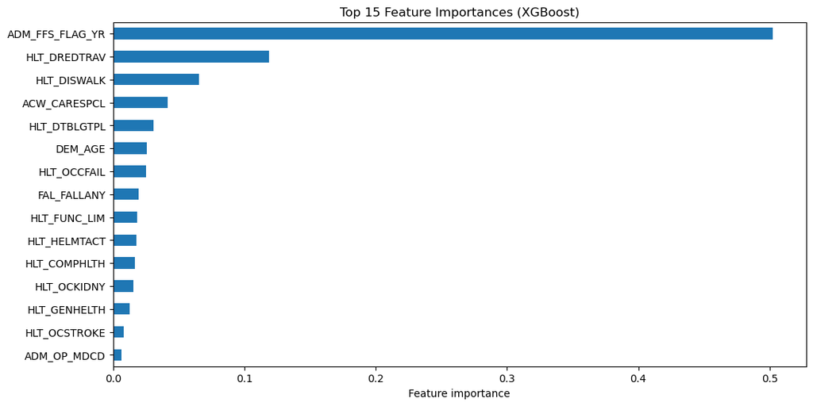

```python
imp = pd.Series(models["XGBoost"][0].feature_importances_, index=X_train.columns)

top15 = imp.sort_values(ascending=False).head(15)

plt.figure()
top15.sort_values().plot(kind="barh")
plt.xlabel("Feature importance")
plt.title("Top 15 Feature Importances (XGBoost)")
plt.show()
```

Since the XGBoost model was one of the best-performing models, I will use it to compare the variables. This graph shows us the most important features that the XGBoost model used when predicting the target variable. We can see that ADM_FFS_FLAG_YR was the highest one by far, which is consistent with the OLS coefficient for this variable being large.

### SHAP Explanations

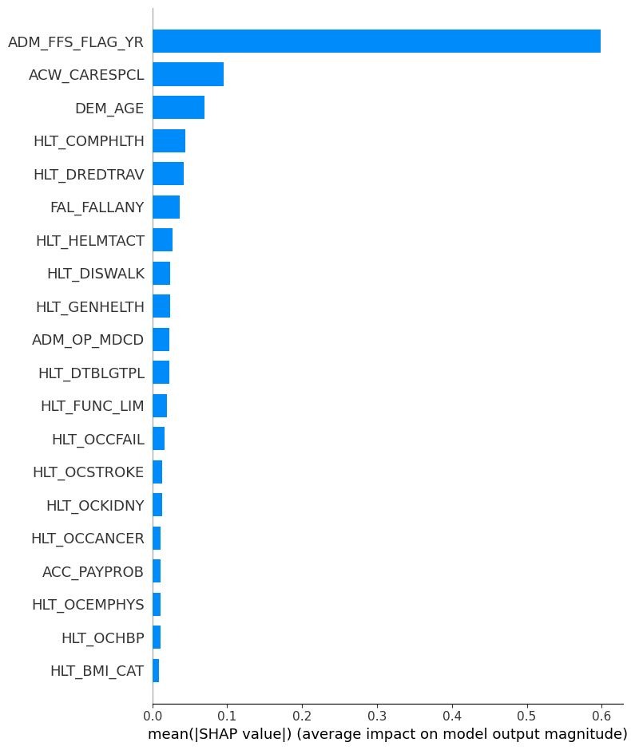

```python
best_tree_model = models["XGBoost"][0]
explainer = shap.TreeExplainer(best_tree_model)

sample_size = min(2000, len(X_test))
X_test_sample = X_test.iloc[:sample_size]
shap_values = explainer.shap_values(X_test_sample)

shap.summary_plot(shap_values, X_test_sample, feature_names=high_cols, plot_type="bar")
```

This shap graph represents how much that predictor pushed the prediction up or down from the average. We can see that it is consistent with the OLS signficance table that has ADM_FFS_FLAG_YR as the most influential variable.

### Feature Ranking Comparison: OLS vs XGBoost vs SHAP

```
Top 15 features — agreement across methods = robust finding

        feature  ols_rank  xgb_rank  shap_rank       p_value
ADM_FFS_FLAG_YR         1         1          1  0.000000e+00
   ACW_CARESPCL         2         4          2 2.796315e-163
        DEM_AGE         3         6          3  3.159458e-63
   HLT_COMPHLTH        29        11          4  4.563554e-02
   HLT_DREDTRAV         4         2          5  2.473014e-28
    FAL_FALLANY         5         8          6  3.619840e-37
   HLT_HELMTACT        11        10          7  1.154367e-09
    HLT_DISWALK        15         3          8  3.897495e-06
   HLT_GENHELTH         6        13          9  8.684324e-22
    ADM_OP_MDCD         9        15         10  1.533981e-11
   HLT_DTBLGTPL         8         5         11  1.124121e-13
   HLT_FUNC_LIM        17         9         12  3.124588e-03
    HLT_OCCFAIL         7         7         13  8.730178e-19
   HLT_OCSTROKE        13        14         14  1.160208e-12
    HLT_OCKIDNY        12        12         15  6.772040e-15
```

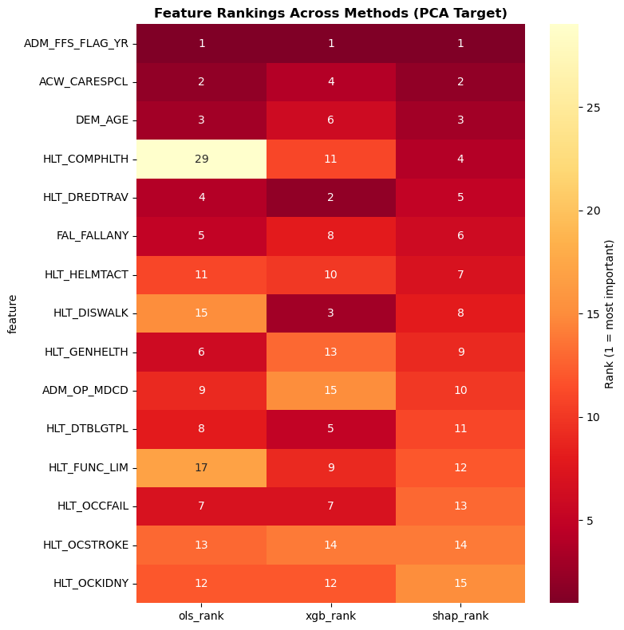

```python
ols_imp = ols_results[['feature', 'coefficient', 'p_value']].copy()
ols_imp['ols_rank'] = ols_imp['coefficient'].abs().rank(ascending=False).astype(int)

xgb_imp = pd.DataFrame({'feature': high_cols, 'xgb_importance': best_tree_model.feature_importances_})
xgb_imp['xgb_rank'] = xgb_imp['xgb_importance'].rank(ascending=False).astype(int)

shap_imp = pd.DataFrame({'feature': high_cols, 'shap_importance': np.abs(shap_values).mean(axis=0)})
shap_imp['shap_rank'] = shap_imp['shap_importance'].rank(ascending=False).astype(int)

comparison = ols_imp.merge(xgb_imp, on='feature').merge(shap_imp, on='feature').sort_values('shap_rank')
print("Top 15 features — agreement across methods = robust finding\n")
print(comparison[['feature', 'ols_rank', 'xgb_rank', 'shap_rank', 'p_value']].head(15).to_string(index=False))

top_15 = comparison.head(15)[['feature', 'ols_rank', 'xgb_rank', 'shap_rank']].set_index('feature')
fig, ax = plt.subplots(figsize=(8, 8))
sns.heatmap(top_15, annot=True, fmt='d', cmap='YlOrRd_r', ax=ax,
            cbar_kws={'label': 'Rank (1 = most important)'})
ax.set_title('Feature Rankings Across Methods (PCA Target)', fontweight='bold')
plt.tight_layout()
plt.show()
```

Finally, by comparing the ols ranking, xgb ranking, and shap ranking of all the predictors, we can get a good overall idea of which predictors performed the best and if it is consistent across all. We can use this information to draw conclusions that will be discussed in the conclusion. Clearly, ADM_FFS_FLAG_YR is the highest ranking variable across all methods, with ACW_CARESPL and DEM_AGE as #2 and #3 in two of the methods, OLS and SHAP. However, HLT_COMPHLTH is 29th on the OLS ranking, 11th on the XGBoost ranking, and 4th on SHAP, meaning it probably is not that signficiant due the disparity between the three tests.

### Prediction with Explanation

```python
def predict_with_explanation(patient_data: dict, n_reasons: int = 5):
    input_df = pd.DataFrame([patient_data])[high_cols]
    log_pred = best_tree_model.predict(input_df)[0]
    raw_pred = np.expm1(log_pred)
    sv = explainer.shap_values(input_df)[0]
    reasons = sorted(zip(high_cols, sv, input_df.values[0]),
                     key=lambda x: abs(x[1]), reverse=True)[:n_reasons]
    return {
        "predicted_utilization_score": round(raw_pred, 2),
        "risk_level": "HIGH" if raw_pred > 50 else "MODERATE" if raw_pred > 20 else "LOW",
        "top_factors": [{"feature": f, "impact": round(float(s), 4),
            "direction": "↑ increases" if s > 0 else "↓ decreases",
            "patient_value": float(v)} for f, s, v in reasons]
    }

sample_patient = X_test.iloc[67].to_dict()
result = predict_with_explanation(sample_patient)
print(f"Predicted score: {result['predicted_utilization_score']}")
print(f"Risk level: {result['risk_level']}\n")
for f in result['top_factors']:
    print(f"  {f['feature']:25s} → {f['direction']} (SHAP: {f['impact']:+.4f})")
```

```
Predicted score: 1.8200000524520874
Risk level: LOW

  ADM_FFS_FLAG_YR           → ↑ increases (SHAP: +0.5281)
  ACW_CARESPCL              → ↓ decreases (SHAP: -0.1858)
  HLT_GENHELTH              → ↓ decreases (SHAP: -0.0707)
  DEM_AGE                   → ↓ decreases (SHAP: -0.0653)
  HLT_COMPHLTH              → ↓ decreases (SHAP: -0.0384)
```

This last section of code is the most important for real-world applications since it takes an input of a sample patient and tells the user which of the variables most affected the outcome of the predicted score and if it increased it or decreased it, along with the risk level. This is helpful because if the risk level is high for a certain patient, we can see which variables played the most significant role in determining that. Therefore, for any given patient, this section shows us how the model figured out why they are utilizing Medicare.

### Conclusion

During the process of this project, I have transformed thousands and thousands of lines of data into actionable insights simply by running it through a machine learning model. Through preprocessing, testing, and computing, I have determined some important information using the XGBoost Regressor model to determine the causes of using Medicare.

Now, up until this point, most of the narration of this project has been fairly technical and has only explained what each section of the code is doing without putting it all together. Now, in this section of the report, I will put together all of my findings in a meaningful way that encompasses all sections and provides an overall understanding of the project.

I found that the Gradient Boosting Model and XGBoosting Model had the best results for the data with the highest R^2s. The worst performing was the Lasso and ElasticNet with the lowest R^2s. This was not surprising since the two boosting models are fairly advanced and are normally the highest performers. Lasso and ElasticNet kinda sucks so it makes sense.

The conclusion of the data showed one variable consistently stood out as the best predictor of utilization score. This variable was ADM_FFS_FLAG_YR. It's a flag variable for whether the beneficiary used Fee-for-Service or Medicare Advantage for that year. Fee-for-Service encompasses parts A and B of Medicare that are defined at the beginning of this project. These parts are hospital insurance and medicare insurance. The government pays directly for each individual doctor visit or hospital visit that the beneficiary goes to. This is different from Medicare Advantage, which is a blanket insurance where the government pays the insurer a fixed amount for medical services.

Additionally, ACW_CARESPCL is the variable that tells us if the person uses a specialist outside the primary health provider. Since it is the second-highest predictor in the model, we can understand that people who use outside specialists also utilize Medicare more than those who don't. Knowing this, we can infer that it would be a good idea for Medicare policies to continue funding and supporting medical specialists so that Medicare can continue being effective and not allow it to go to waste.

Lastly, DEM_AGE is the other high predictor that all 3 of the methods used to predict utilization. From this, we can understand that a person's age plays a big role in determining if they utilize Medicare or not. This makes sense since older people generally have more health problems than younger people. This shows us that the model is working! It is getting a basic, intuitive part of the model correct and helps us confirm that these findings are not just random.

Overall, my biggest takeaways from this project were a better understanding of Medicare and how it worked. I originally didn't know how the system worked and what it did specifically, but after combing through variables, choosing predictors, and constructing a utilization score, I have a better idea of what it does. This project has been meaningful to me and has also helped me understand the medical problems that people face later in life. It helps me to be more compassionate and understanding of people's situations that are fairly far removed from my college bubble.

The next steps from here would be to make an interactive dashboard to better visualize the results and test with various settings. This would help non-technical audiences understand what this project was about. This could be accomplished using Streamlit or other apps.